# simon-5507-06-slides

## Topics to be covered

- What you will learn
  - Breaking apart datasets
  - Combining datasets
  - simon-5507-06-demo1
  - Longitudinal data and repeated measures
  - Time-constant and time-varying data
  - todd-5507-06-demo2

## What is a dataset option?

- Inserted next to a dataset name
  - Inside parentheses
  - Either in the data statement or the set statement.

```
data small_piece;
    set big_piece(obs=10);
run;
```

## Breaking up data

- Column subsets
  - `keep` statement or dataset option
  - `drop` statement or dataset option
- Row subset
  - `obs` dataset option
  - `firstobs` dataset option
  - `if` statement

## The keep dataset option with the set statement

```
* Using keep in the set statement
data small_piece;
    set big_piece (keep = variable_list);
`   optional processing steps;
run;
```

## The keep statement inside the data step

```
* Using keep in the data step
data small_piece;
    set big_piece;
    optional processing steps;
    keep = variable_list;
    more optional processing steps;
run;
```

## The keep dataset option with the data statement

```
* Using keep in the data statement
data small_piece(keep = variable_list);
    set big_piece;
    optional processing steps;
run;
```

## The drop statement

- Inverse of the keep statement
- Same locations
  - set statement
  - data step
  - data statement

## The obs dataset option

```
data small_piece;
    set big_piece(obs=n);
    optional processing steps;
run;
```

```
data small_piece(obs=n);
    set big_piece;
    optional processing steps;
run;
```

## The firstobs dataset option

```
data small_piece;
    set big_piece(firstobs=n);
    optional processing steps;
run;
```

```
data small_piece(firstobs=n);
    set big_piece;
    optional processing steps;
run;
```

## The if statement

```
data small_piece;
    set big_piece;
    optional processing steps;
    if logical-condition;
    more optional processing steps;
run;
```

```
data small_piece;
    set big_piece;
    optional processing steps;
    if logical-condition then delete;
    more optional processing steps;
run;
```

## Break #1

- What you have learned
  - Breaking apart datasets
- What’s coming next
  - Combining datasets

## Combining using set statement

- `set first-dataset second-dataset`
  - Stacks one beneath the other
  - Variable names and types should match
  - Number of rows do not have to match
  - Can combine more than two datasets

## Combining datasets using merge statement (without a by statement)

- `merge first-dataset second-dataset`
  - Stacks side-by-side
  - Beware of misalignment
  - Variable names should not match
  - Number of rows should match

## Using the by statement

- `by key`
  - Better way to handle mismatching row numbers
  - The key controls the match
  - Data MUST be sorted by key
  - Could have two or more keys

## Example of an inner join

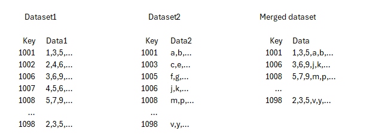

## Example of a left join

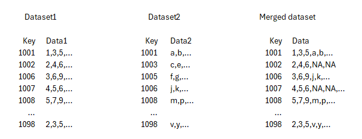

## Example of a right join

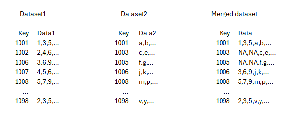

## Example of a full or outer join

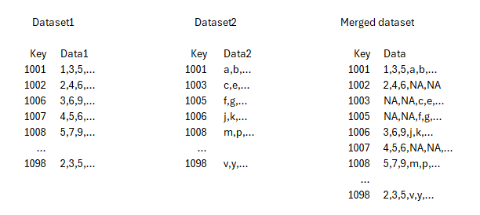

## Example of a one-to-one join

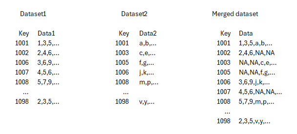

## Example of a one-to-many join

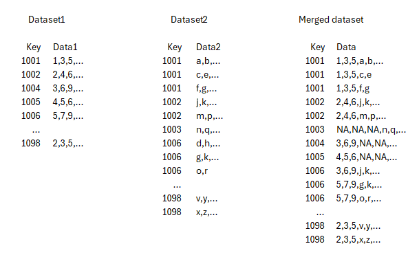

## The dangers of misalignment

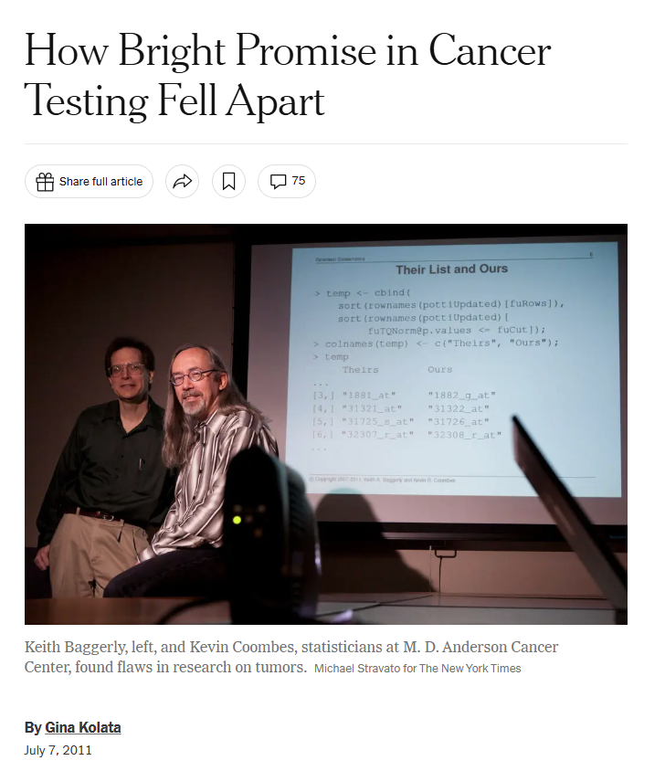

## When should you use a many-to-one join?

- Very dependent on context
- Adding labels to category codes
- Adding time-varying data
- Try to avoid many-to-many joins

## How should you choose between inner, left, right, and outer joins?

- Also very dependent on context
- Filling in gaps
- Complete cases only

## An example of a dataset with labels

[figure not shown]

## Break #2

- What you have learned
  - Combining datasets
- What’s coming next
  - simon-5507-06-demo1

## Documentation header

```
    simon-5507-06-demo1.sas
    author: Steve Simon
    date created: 2026-06-25
    purpose: to illustrate managing multiple datasets
    license: public domain;
```

## File locations

```
%let path=q:/5507-2025b/06;

ods pdf
    file= "&path/results/simon-5507-06-demo1.pdf";

libname storage
    "&path/data/";
```

## More file locations

```
filename d70yr
    "&path/data/draft70yr.dat.txt";

filename d71yr
    "&path/data/draft71yr.dat.txt";

filename d70mn
    "&path/data/draft70mn.dat.txt";
```

## Read tab delimited files

```
data storage.draft70yr;
    infile d70yr;
    input
        day_of_year
        draft_order
        month;
run;

data storage.draft71yr;
    infile d71yr;
    input
        day_of_year
        draft_order
        month;
run;
```

## Print the first few rows

```
proc print
    data=storage.draft70yr (obs=10);
    title1 "First ten rows of the 1970 draft lottery data";
    title2 "Using a year long format";
    footnote "Steve Simon, 2026-06-25, SAS version 9.4";
run;

proc print
    data=storage.draft71yr (obs=10);
    title1 "First ten rows of the 1971 draft lottery data";
    title2 "Using a year long format";
run;
```

## Create small subsets of the data

```
data dec_1970a;
    set storage.draft70yr;
    if month=12;
    year=1970;
run;

data dec_1971a;
    set storage.draft71yr;
    if month=12;
    year=1971;
run;
```

## Stack datasets one beneath the other

```
data dec_stack1;
    set dec_1970a dec_1971a;
run;

proc print
    data=dec_stack1 (obs=10);
    title1 "First ten rows of stacked data";
run;
```

## Boxplot comparing 1970 and 1971

```
ods graphics /
    height=2.5 in width=6 in;

proc sgplot
    data=dec_stack1;
  hbox draft_order / category=year nofill;
  yaxis label=" ";
  title1 "The draft orders are much smaller in 1970";
  title3 "and the median, which should be around half of 366";
  title4 "is closer to 100";
run;

ods graphics on / reset=all;
```

## Create small subsets of the data

```
data dec_1970b (rename=(draft_order=draft_order_1970));
    set storage.draft70yr;
    if month=12;
run;

data dec_1971b (rename=(draft_order=draft_order_1971));
    set storage.draft71yr;
    if month=12;
run;
```

## Stack the two datasets side by side and print the results

```
data dec_stack2;
   merge dec_1970b dec_1971b;
run;

proc print
    data=dec_stack2(obs=10);
    title1 "Partial listing of side by side stacked data";
run;
```

## Read a fixed width file

```
data storage.draft70mn;
    infile d70mn;
    input
        jan_order 3-5
        feb_order 7-9
        mar_order 11-13
        apr_order 15-17
        may_order 19-21
        jun_order 23-25
        jul_order 27-29
        aug_order 31-33
        sep_order 35-37
        oct_order 39-41
        nov_order 43-45
        dec_order 47-49;
    day_of_month=_n_;
run;
```

## Print a small piece of the data.

```
proc print
    data=storage.draft70mn;
    var jan_order -- may_order;
    title1 "First five columns of the 1970 draft lottery data";
    title2 "Using a month long format";
run;
```

## Convert monthly data to yearly data

```
proc transpose
    data=storage.draft70mn
    out=stack3 (rename=(col1=draft_order));
    by day_of_month;
    var jan_order -- dec_order;
run;

proc print
   data=stack3;
   title1 "Listing of transposed draft70mn";
run;
```

## Add day_of_month column

```
data day_of_month;
  infile "&path/data/day_of_month.txt";
  input day_of_month;
run;

data storage.draft70yr;
    set storage.draft70yr;
    merge day_of_month;
run;
```

## Convert yearly data to monthly data

```
proc sort
    data=storage.draft70yr;
    by day_of_month month;
run;

proc transpose
    data=storage.draft70yr
    out=stack4
    prefix=Month;
    id Month;
    by day_of_month;
    var draft_order;
run;

proc print
    data=stack4;
run;
```

## Don’t forget to close your PDF file

```
ods pdf close;
```

## Live demo

## Break #3

- What you have learned
  - simon-5507-06-demo1
- What’s coming next
  - Longitudinal data and repeated measures

## What is longitudinal/repeated measures data

- Longitudinal data
  - Measurement of the same subject at different times.
- Repeated measures data
  - Measurement of the same subject under different conditions
- No independence assumption
  - Varying data analysis approaches
  - Similar data management approaches

## Longitudinal data

[figure not shown]

## Repeated measures data

[figure not shown]

## Time-constant and Time-varying data

- Time constant data
  - Does not change across time/repeated measures
  - Should be stored as one row per patient
- Time varying data
  - Changes across time/repeated measures
  - Could be stored one row per patient
  - Could be stored one row per time/measure

## The wide format

$\begin{matrix} 1 & O_{11} & O_{12} & O_{13} & O_{14} & A_1 & B_1 & \cdots \\ 2 & O_{21} & O_{22} & O_{23} & O_{24} & A_2 & B_2 & \cdots \\ 3 & O_{31} & O_{32} & O_{33} & O_{34} & A_3 & B_3 & \cdots \\ 4 & O_{41} & O_{42} & O_{43} & O_{44} & A_4 & B_4 & \cdots \\ 4 & O_{51} & O_{52} & O_{53} & O_{54} & A_5 & B_5 & \cdots \\ \vdots & \vdots & \vdots & \vdots & \vdots & \vdots & \vdots & \end{matrix}$

## The long format

$\begin{matrix} 1 & 1 & O_{11} & A_1 & B_1 & \cdots \\ 1 & 2 & O_{12} & A_1 & B_1 & \cdots \\ 1 & 3 & O_{13} & A_1 & B_1 & \cdots \\ 1 & 4 & O_{14} & A_1 & B_1 & \cdots \\ 2 & 1 & O_{21} & A_2 & B_2 & \cdots \\ 2 & 2 & O_{22} & A_2 & B_2 & \cdots \\ \vdots & \vdots & \vdots& \vdots & \vdots & \end{matrix}$

## Which format is better?

- Neither is uniformly superior
- Long format
  - Time constant data is repeated
  - Extra space requirements
  - Increase chance for data quality problems
- Wide format
  - Excessive number of columns
  - Difficult to scroll left/right
- Different analyses require different formats
  - Correlations need the wide format
  - Plots require the long format

## Break #4

- What you have learned
  - Longitudinal data and repeated measures
- What’s coming next
  - Time-constant and time-varying data

## Storing time-constant and time-varying data in separate datasets

- Best approach: split your data (normalization)
- Time-constant data in one table
  - Always one row per patient
- Time-varying data in another table
  - Could be one row per patient (wide format)
  - Could be multiple rows per patient (long format)

## Converting from long to wide format

```
proc transpose
    data=
    out= ;
    id ;
    by ;
    var ;
run;
```

## Converting from wide to long format

```
proc transpose
    data=
    out= ;
    by Subject;
    var ;
run;
```

## Break #5

- What you have learned
  - Time-constant and time-varying data
- What’s coming next
  - todd-5507-06-demo2

## Documentation header

```
todd-5507-06-demo2.sas
author: Reagan Todd, Steve Simon
date created: 2025-09-09
purpose: to understand how to manipulate data widths.
license: public domain
```

## File locations

```
%let path=q:/5507-2025b/06;

ods pdf
    file= "&path/results/todd-5507-06-demo2.pdf";

libname storage
    "&path/data/";

filename balance1
    "&path/data/balance-measures-long.txt";

filename balance2
    "&path/data/balance-measures-wide.txt";
```

## Read long format

```
data storage.balance_long;
    infile balance1 delimiter= "09"X firstobs=2;
    input
        Subject
        Sex $
        Age
        Height
        Weight
        Surface $
        Vision $
        CTSIB;
run;
```

## Print data and metadata

```
proc print
    data=storage.balance_long (obs=12);
    title1 "First twelve rows of the long format balance data";
    footnote "Reagan Todd, 2025-09-09, SAS version 9.4";
run;

proc contents data=storage.balance_long;
    title1 "Contents of the long balance data";
run;
```

## Read wide format

```
data storage.balance_wide;
    infile balance2 delimiter= "09"X firstobs=2;
    input
        Subject
        Sex $
        Age
        Height
        Weight
        NO1
        NO2
        NC1
        NC2
        ND1
        ND2
        FO1
        FO2
        FC1
        FC2
        FD1
        FD2;
run;
```

## Print data and metadata

```
proc print
    data=storage.balance_wide (obs=10);
    title1 "first ten rows of the wide balance data";
run;

proc contents data=storage.balance_wide;
    title1 "Contents of the wide balance data";
run;
```

## Create time constant data from long format

```
data storage.time_constant_long;
    set storage.balance_long;
    keep Subject Sex Age Height Weight;
run;

proc sort
    data=storage.time_constant_long nodup;
    by _all_;
run;

proc print
   data=storage.time_constant_long (obs=10);
   title "First ten rows of time constant data";
run;
```

## Create time varying data from long format

```
data storage.time_varying_long;
    set storage.balance_long;
    keep Subject Surface Vision CTSIB;
run;

proc print
   data=storage.time_varying_long (obs=10);
   title "First ten rows of time constant data";
run;
```

## Creating time constant data from wide format

```
data storage.time_constant_wide;
    set storage.balance_wide;
    keep Subject Sex Age Height Weight;
run;

proc print
   data=storage.time_constant_wide (obs=10);
   title "First ten rows of time-constant data";
run;
```

## Creating time varying data from wide format

```
data storage.time_varying_wide;
    set storage.balance_wide;
    keep Subject NO1 NO2 NC1 NC2 ND1 ND2 FO1 FO2 FC1 FC2 FD1 FD2;
run;

proc print
   data=storage.time_varying_wide (obs=10);
   title "First ten rows of time-varying data";
run;
```

## Transposing long to wide, part 1

```
proc sort
    data=storage.time_varying_long;
    by Surface Vision Subject;
run;

data storage.time_varying_long;
    set storage.time_varying_long;
    by Surface Vision Subject;
    if first.Subject
        then rep=1;
        else rep=2;
run;
```

## Transposing long to wide, part 2

```
proc sort
    data=storage.time_varying_long;
    by Subject Surface Vision Rep;
run;

proc transpose
    data=storage.time_varying_long
    out=wide_conversion;
    id Surface Vision rep;
    by Subject;
    var CTSIB;
run;

proc print
    data=wide_conversion (obs=10);
    title1 "Listing of long converted to wide format";
run;
```

## Transposing wide to long

```
proc sort
    data=storage.time_varying_wide;
    by Subject;
run;

proc transpose
    data=storage.time_varying_wide
    out=long_conversion;
    by Subject;
    var NO1--FD2;
run;

proc print
    data=long_conversion (obs=10);
    title1 "Listing of wide converted to long format";
run;
```

## Always remember to close your pdf file

```
ods pdf close;
```

## Live demo

## Summary

- What you have learned
  - Breaking apart datasets
  - Combining datasets
  - simon-5507-06-demo1
  - Longitudinal data and repeated measures
  - Time-constant and time-varying data
  - todd-5507-06-demo2